# Homework 1

Halenur Kocaman-2015402036

## Libraries

```r
library(readxl)
library(ggplot2)
library(tidyverse)
```

## TASK 1

To begin the tasks, data is extracted from an excel file. Since the data types of all columns are character, numeric columns and categorical columns that will be used for the analysis are converted to numeric and factor types accordingly.

```r
epl <- read_excel("C:/Users/asus/Desktop/all_data.xlsx")
data<-as.data.frame(epl[,1:56])
#str(data)
data[,-c(1,2,3,4,5,8,11,12)]<-apply(data[,-c(1,2,3,4,5,8,11,12)],2,as.numeric)
data[,8]<-as.factor(data[,8])
task1<-data[,6:7]
task1$HG_AG<-task1$FTHG-task1$FTAG
```

### A) Home Score

As it can be observed from the graphs below, home score goals look like having a Poisson distribution.

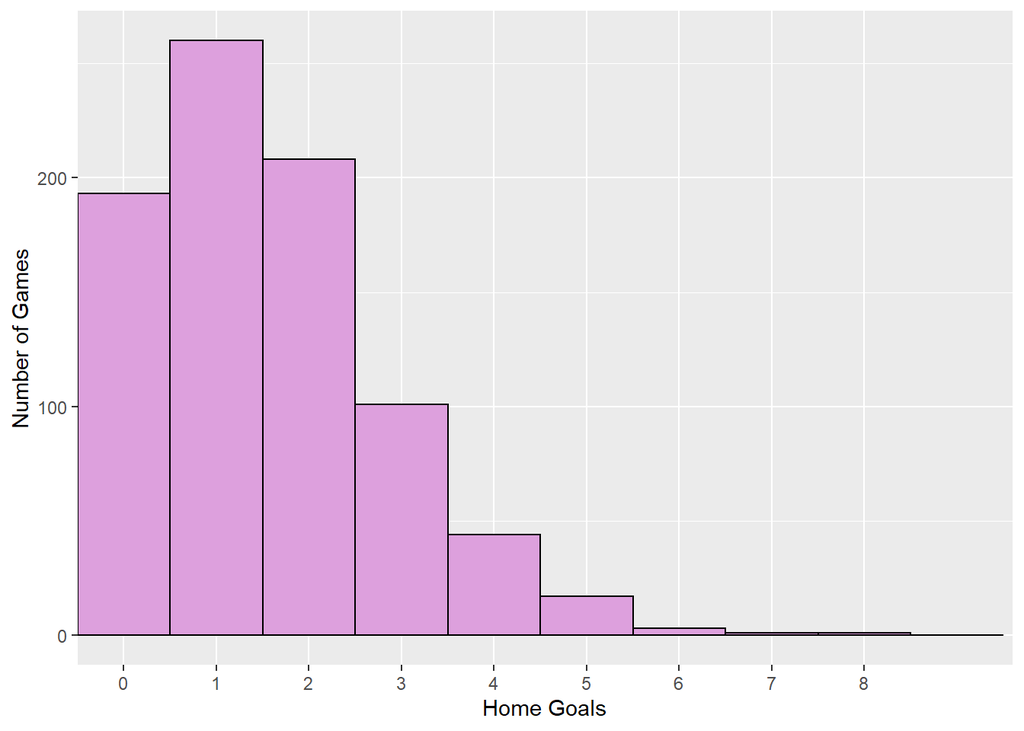

```r
ggplot(task1, aes(FTHG)) +
  geom_histogram(binwidth= 1, color="black", fill="plum") +
  xlab("Home Goals") + ylab("Number of Games") +
  scale_x_discrete(limits=c(0:max(task1$FTHG)))
```

To find real probablity distribution with the Poisson distribution claim, lambda value is calculated using sample mean of the Home Score goals. According to Poisson distribution, expected number of games for each bin is calculated. Looking at the second graph, the line shows the Poisson distribution values while the bars are showing the real distribution for each goal number. Hence, this graph validates that home goals have Poisson distribution.

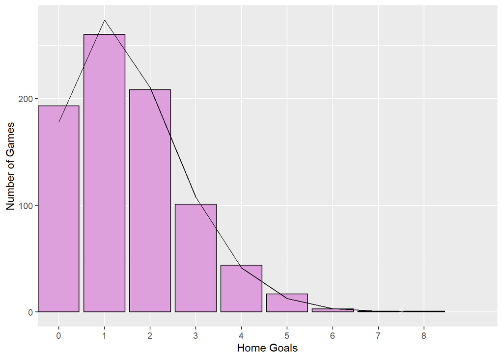

```r
hg<-task1 %>%
  group_by(FTHG) %>%
  summarise(obs=n())

hg$exp_pois<-dpois(c(0:max(task1$FTHG)),lambda= mean(task1$FTHG))*nrow(task1)

ggplot(hg, aes(FTHG,obs)) +
  geom_col(color="black", fill="plum")+
  geom_line(aes(y=exp_pois))+
  scale_x_discrete(limits=c(0:max(task1$FTHG)))+
  xlab("Home Goals") + ylab("Number of Games")
```

### B) Away Score

Away score distribution look very similar to home score distribution. It also looks like a Poisson distribution while looking at the graph below.

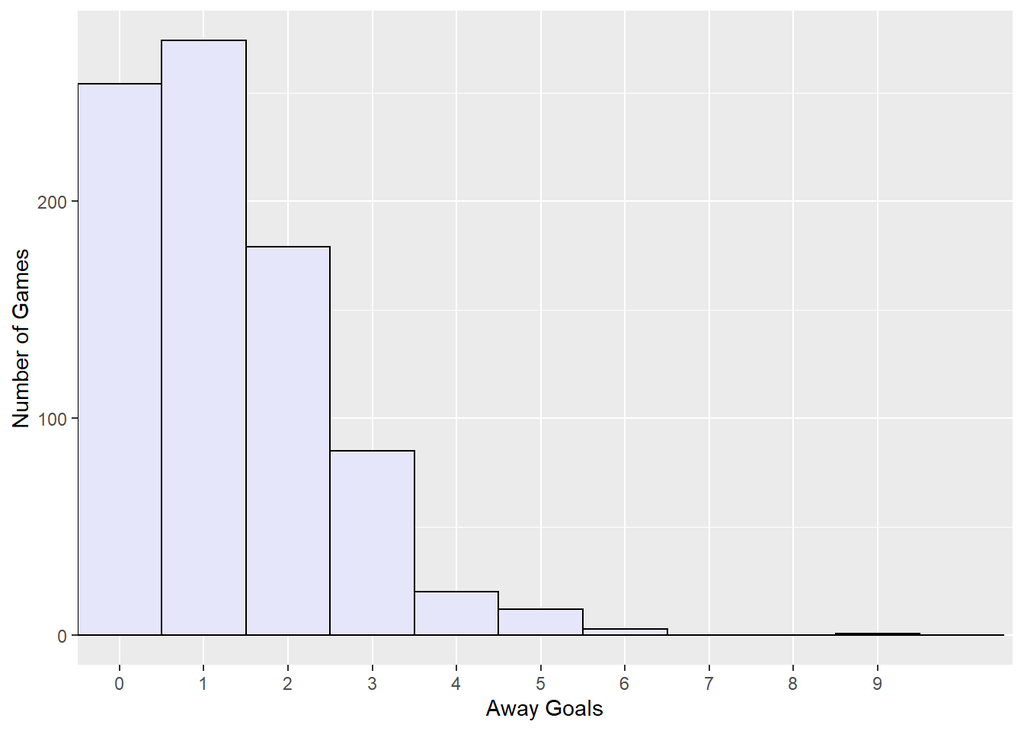

Doing the same calculations for away goals with the Poisson distribution claim, expected values for each bin are calculated. The graph below shows that away goals also show Poisson distribution since the expected values are very close to the real values.

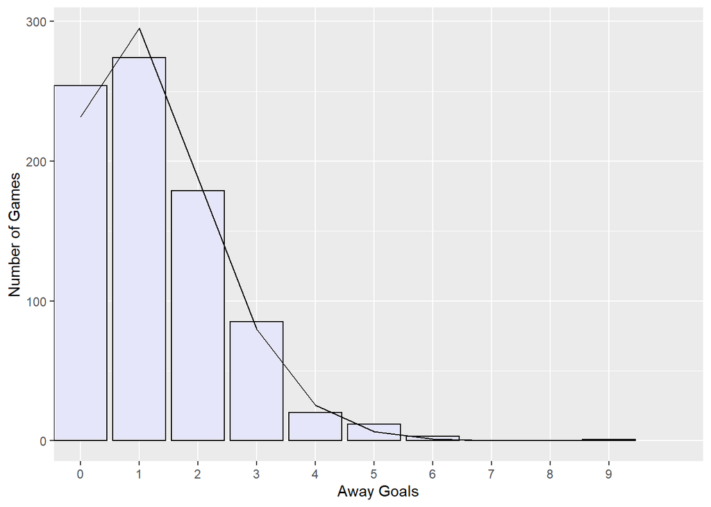

```r
ag<-task1 %>%
  group_by(FTAG) %>%
  summarise(obs=n())

ag[10,]<-ag[8,]
ag[8,]<-c(7,0)
ag[9,]<-c(8,0)

ag$exp_pois<-dpois(c(0:max(task1$FTAG)),lambda= mean(task1$FTAG))*nrow(task1)

ggplot(ag, aes(FTAG,obs)) +
  geom_col(color="black", fill="lavender")+
  geom_line(aes(y=exp_pois))+
  scale_x_discrete(limits=c(0:max(task1$FTAG)))+
  xlab("Away Goals") + ylab("Number of Games")
```

### C) Home-Away Score

Home-away score looks like Normal distribution when a histogram is plotted.

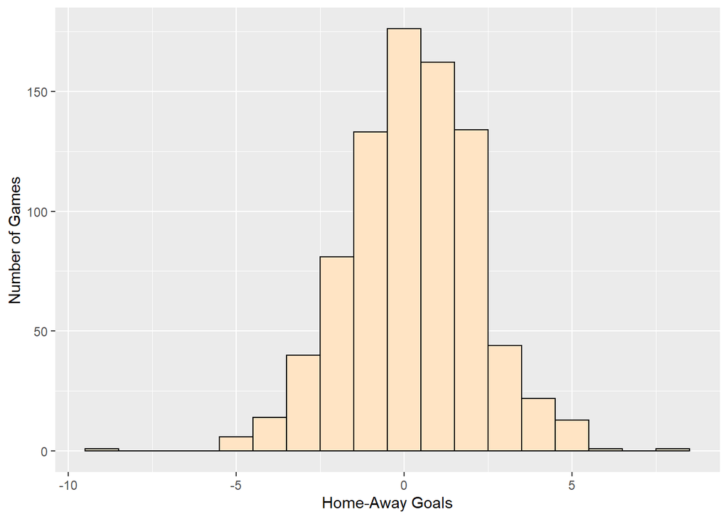

```r
#Home-Away Goals Histogram
ggplot(task1, aes(HG_AG)) +
  geom_histogram(binwidth= 1, color="black", fill="bisque") +
  xlab("Home-Away Goals") + ylab("Number of Games")
```

The claim is validated when a normal distribution graph is made using the sample mean and sample standard deviation of home-away goals as parameters.

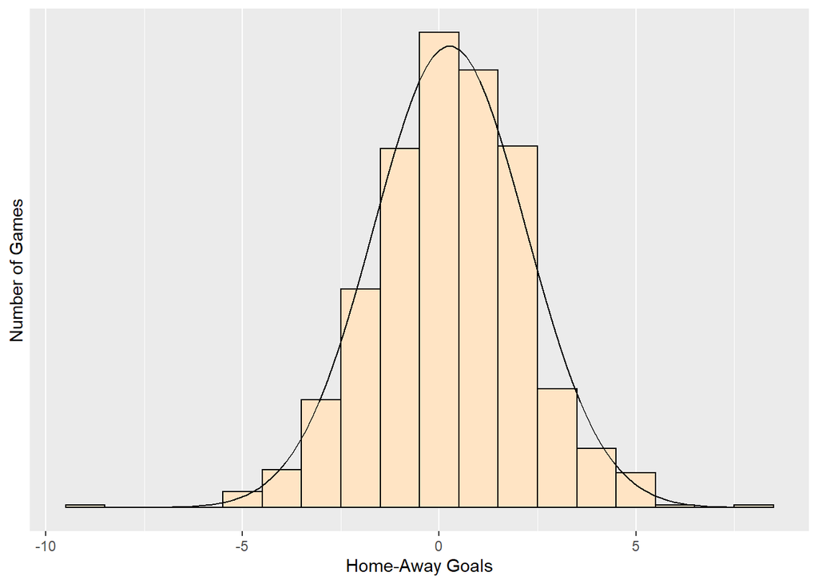

```r
#Calculation
m<-mean(task1$HG_AG)
sdev<-sd(task1$HG_AG)

#Home-Away Goals Histogram with Density-red shows the normal distribution
ggplot(task1, aes(HG_AG)) +
  geom_histogram(aes(y=..density..),binwidth= 1, color="black", fill="bisque") +
  xlab("Home-Away Goals") + ylab("Number of Games") +
  stat_function(fun = dnorm, args = list(mean = m, sd = sdev)) +
  scale_y_continuous(breaks = NULL)
```

## TASK 2

### Bet 365

Firstly, the data containing the basic information about the matches and the odds of Bet 365 are extracted from the data as a new data frame. Then, in order to count the number of draw matches, a binary column named “is_draw” is added. The probabilities for home win, away win and draw are calculated using the 1/odd formula. Then these probabilities are normalized dividing them by sum of all the probabilities. Additionally, the difference between home win probability and away win probability is calculated using two different probability calculation approach.

```r
b365<-data[,c(1:8,23:27)]
b365$is_draw<-ifelse(b365$FTR=="D",1,0)

b365$P_home<-1/b365$B365H
b365$P_draw<-1/b365$B365D
b365$P_away<-1/b365$B365A
b365$sum_prob<-b365$P_home + b365$P_draw + b365$P_away

b365$NP_home<-b365$P_home/b365$sum_prob
b365$NP_draw<-b365$P_draw/b365$sum_prob
b365$NP_away<-b365$P_away/b365$sum_prob

b365$ph_pa<-b365$P_home-b365$P_away
b365$nph_npa<-b365$NP_home-b365$NP_away
```

The graph below shows that the probabilty of draw reaches its maximum when P(Home Win)-P(Away Win) is around zero. On the other hand, draw probability decreases when the difference between P(Home Win) and P(Away Win) gets larger.

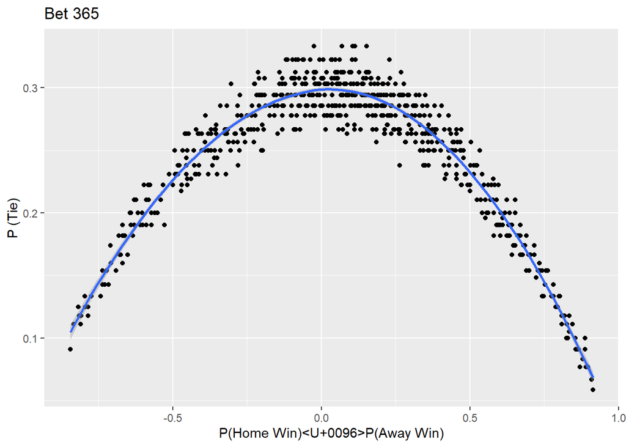

```r
ggplot(b365, aes(ph_pa, P_draw)) +
  geom_point()+ xlab("P(Home Win)㤼㸶P(Away Win)") +
  ylab("P (Tie)") +  ggtitle("Bet 365")+
  geom_smooth()
```

To compare the actual match outcomes with the predictions, x axis is divided into bins by 0.05 increments. Then the number of draws and total matches in these intervals are found. The actual probabilities for draw are calculated by dividing draw numbers by total match numbers in that bin.

```r
b365$p_range<-cut(b365$ph_pa,breaks = seq(-1,1,by=0.05))
b<-b365 %>%
  group_by(p_range) %>%
  summarise(draw_num=sum(is_draw), obs=n())

b$ort<-seq(-0.825,0.925,by=0.05)

b$draw_real_prob<-b$draw_num/b$obs
```

In the plot below, red stars show the real draw probability according to the match outcomes in that bin. Generally, in the long run real draw probabilities are less than what Bet 365 offers. However, in the area between 0 to 0.25 one can more likely to make money in the long run. Three points in that interval have higher draw probabilites than the bookmaker offers for those matches.

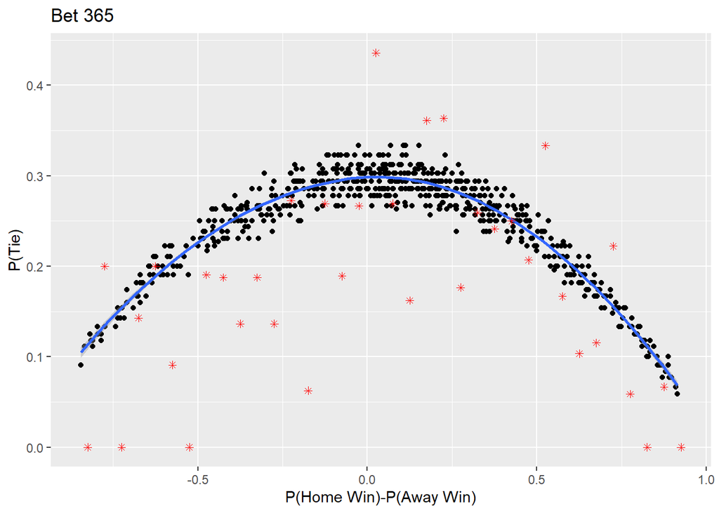

```r
ggplot() +
  geom_point(data=b365, aes(x=ph_pa, y=P_draw))+ geom_smooth(data=b365, aes(x=ph_pa, y=P_draw))+
  geom_point(shape=8,data=b,aes(x=ort,y=draw_real_prob),colour="red") +
  xlab("P(Home Win)-P(Away Win)")+
  ylab("P(Tie)")+ ggtitle("Bet 365")
```

### Bet and Win

The same probability calculations are done for Bet and Win.

```r
bw<-data[,c(1:8,23:24,28:30)]
bw$is_draw<-ifelse(bw$FTR=="D",1,0)
bw$P_home<-1/bw$BWH
bw$P_draw<-1/bw$BWD
bw$P_away<-1/bw$BWA
bw$sum_prob<-bw$P_home+bw$P_draw+bw$P_away

bw$NP_home<-bw$P_home/bw$sum_prob
bw$NP_draw<-bw$P_draw/bw$sum_prob
bw$NP_away<-bw$P_away/bw$sum_prob

bw$ph_pa<-bw$P_home-bw$P_away
bw$nph_npa<-bw$NP_home-bw$NP_away
```

In the scatter plot below, similar behaviour of data can be observed with the previous bookmaker analyzed. However, the tie probability calculated by the odds of bookmaker is higher comparing to Bet 365, when P(Home Win)-P(Away Win) is near zero.

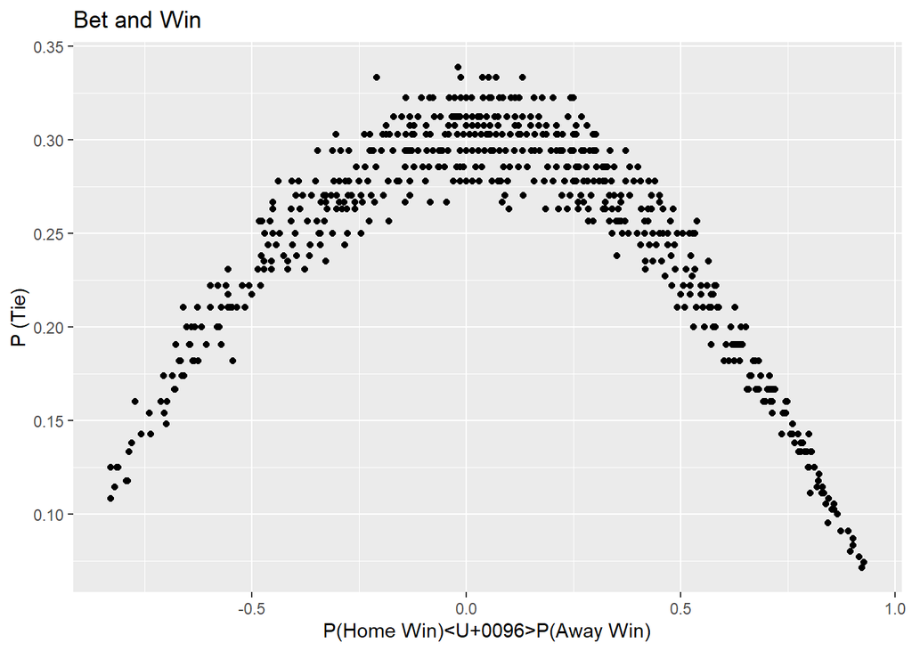

```r
ggplot(bw, aes(ph_pa, P_draw)) +
  geom_point()+ xlab("P(Home Win)㤼㸶P(Away Win)") +
  ylab("P (Tie)") + ggtitle("Bet and Win")
```

Draw probabilities for the real match outcomes are calculated using the same approach with the previous bookmaker.

```r
bw$p_range<-cut(bw$ph_pa,breaks = seq(-1,1,by=0.05))

bw_df<-bw %>%
  group_by(p_range) %>%
  summarise(draw_num=sum(is_draw), obs=n())

bw_df$ort<-seq(-0.825,0.925,by=0.05)

bw_df$draw_real_prob<-bw_df$draw_num/bw_df$obs
```

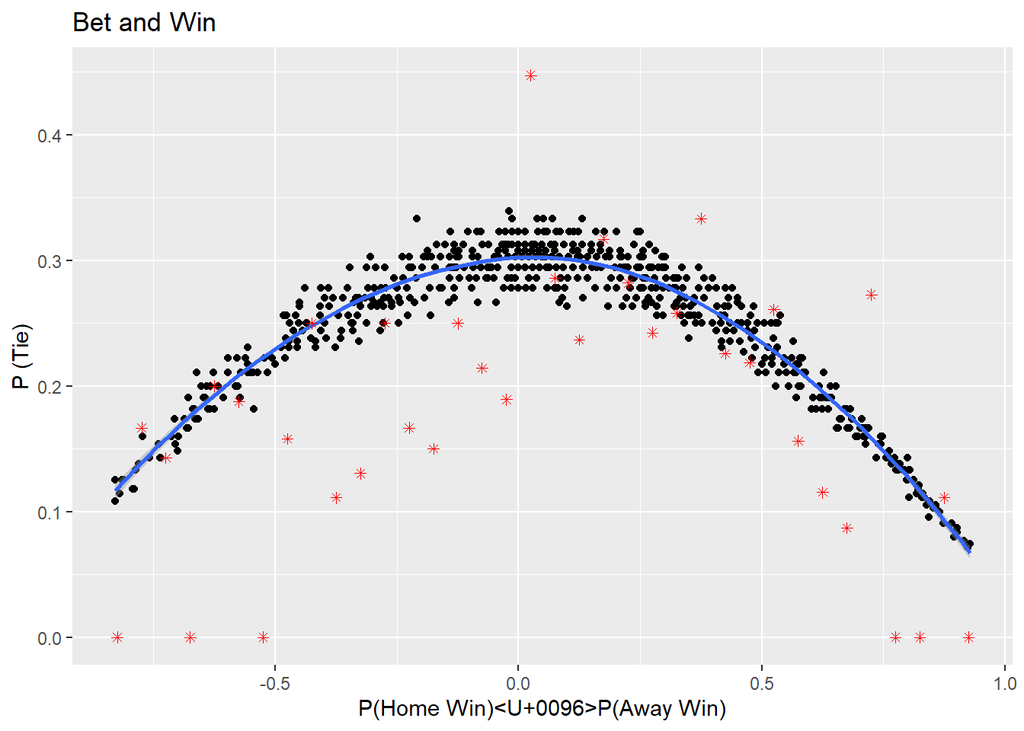

```r
ggplot() +
  geom_point(data=bw, aes(x=ph_pa, y=P_draw))+ geom_smooth(data=bw, aes(x=ph_pa, y=P_draw))+
  geom_point(data=bw_df,aes(x=ort,y=draw_real_prob),shape=8,colour="red")+
  xlab("P(Home Win)㤼㸶P(Away Win)") +
  ylab("P (Tie)") + ggtitle("Bet and Win")
```

### Some Bookmaker

The same steps are followed with the previous bookmakers to do necessary probability calculations.

```r
iw<-data[,c(1:8,23:24,31:33)]
iw$is_draw<-ifelse(iw$FTR=="D",1,0)
iw$P_home<-1/iw$IWH
iw$P_draw<-1/iw$IWD
iw$P_away<-1/iw$IWA
iw$sum_prob<-iw$P_home+iw$P_draw+iw$P_away

iw$NP_home<-iw$P_home/iw$sum_prob
iw$NP_draw<-iw$P_draw/iw$sum_prob
iw$NP_away<-iw$P_away/iw$sum_prob

iw$ph_pa<-iw$P_home-iw$P_away
iw$nph_npa<-iw$NP_home-iw$NP_away
```

The scatter plot for Some Bookmaker can be found below:

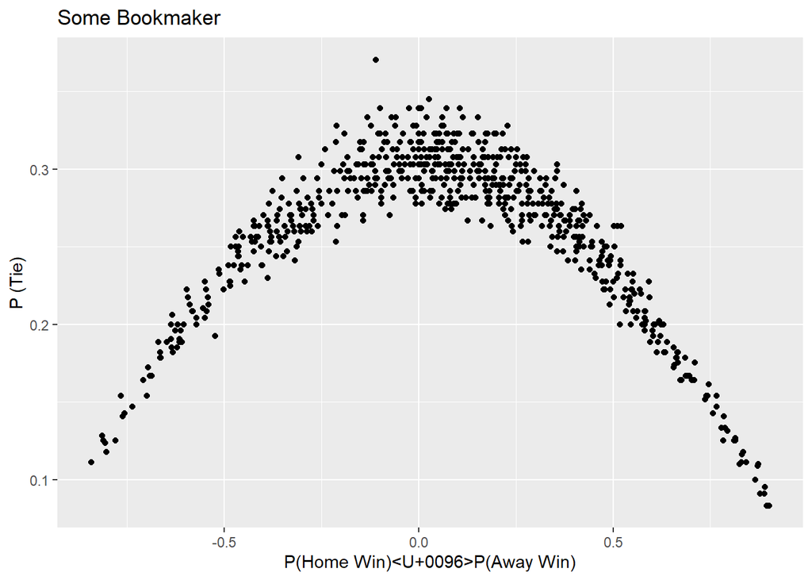

```r
ggplot(iw, aes(ph_pa, P_draw)) +
  geom_point()+ xlab("P(Home Win)㤼㸶P(Away Win)") +
  ylab("P (Tie)") + ggtitle("Some Bookmaker")
```

Draw probabilities for the real match outcomes are calculated using the same approach with the previous bookmakers.

```r
iw$p_range<-cut(iw$ph_pa,breaks = seq(-1,1,by=0.05))

iw_df<-iw %>%
  group_by(p_range) %>%
  summarise(draw_num=sum(is_draw), obs=n())

iw_df$ort<-seq(-0.825,0.925,by=0.05)

iw_df$draw_real_prob<-iw_df$draw_num/iw_df$obs
```

Plot below shows that probabilities proposed by the bookmaker are higher than the actual probabilities. However, in the same interval with the other two bookmaker, there is a point which yields profit in the long run.

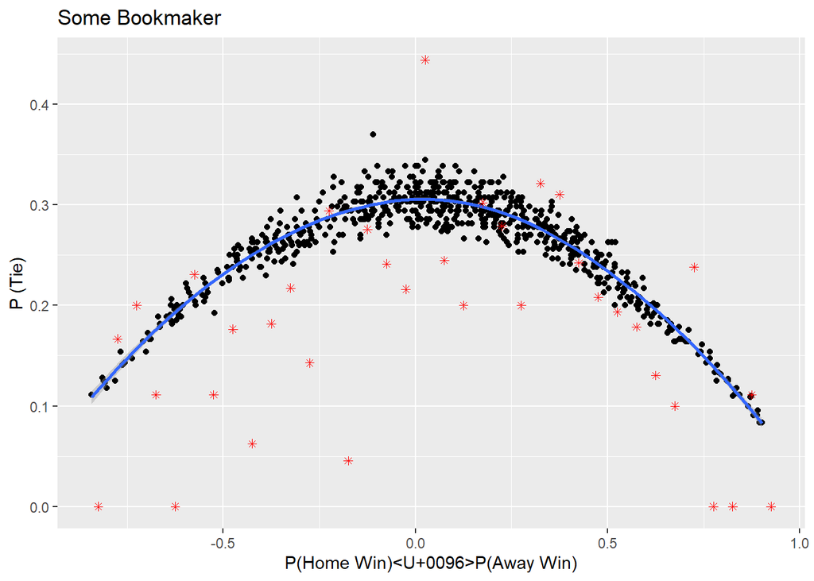

```r
ggplot() +
  geom_point(data=iw, aes(x=ph_pa, y=P_draw))+ geom_smooth(data=iw, aes(x=ph_pa, y=P_draw))+
  geom_point(data=iw_df,aes(x=ort,y=draw_real_prob),colour="red",shape=8)+
  xlab("P(Home Win)㤼㸶P(Away Win)") +
  ylab("P (Tie)") + ggtitle("Some Bookmaker")
```

### Pinnacle

To begin with, the same probability calculations are done for Pinnacle.

```r
ps<-data[,c(1:8,23:24,34:36)]
ps$is_draw<-ifelse(ps$FTR=="D",1,0)
ps$P_home<-1/ps$PSH
ps$P_draw<-1/ps$PSD
ps$P_away<-1/ps$PSA
ps$sum_prob<-ps$P_home+ps$P_draw+ps$P_away

ps$NP_home<-ps$P_home/ps$sum_prob
ps$NP_draw<-ps$P_draw/ps$sum_prob
ps$NP_away<-ps$P_away/ps$sum_prob

ps$ph_pa<-ps$P_home-ps$P_away
ps$nph_npa<-ps$NP_home-ps$NP_away
```

The scatter plot shows the similar behaviour with the other bookmakers. The plot showing the relationship can be found below:

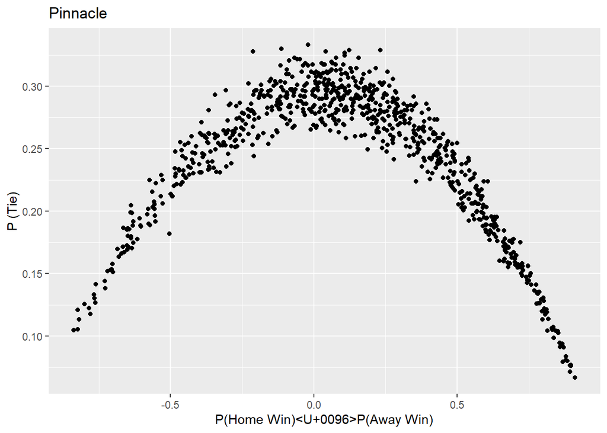

```r
ggplot(ps, aes(ph_pa, P_draw)) +
  geom_point()+ xlab("P(Home Win)㤼㸶P(Away Win)") +
  ylab("P (Tie)") + ggtitle("Pinnacle")
```

Real draw probabilities are calculated in order to compare with the ones that Pinnacle offers.

```r
ps$p_range<-cut(ps$ph_pa,breaks = seq(-1,1,by=0.05))

ps_df<-ps %>%
  group_by(p_range) %>%
  summarise(draw_num=sum(is_draw), obs=n())

ps_df$ort<-seq(-0.825,0.925,by=0.05)

ps_df$draw_real_prob<-ps_df$draw_num/ps_df$obs
```

The same comment applies for this bookmaker. The interval near zero is still profitable in the long run.

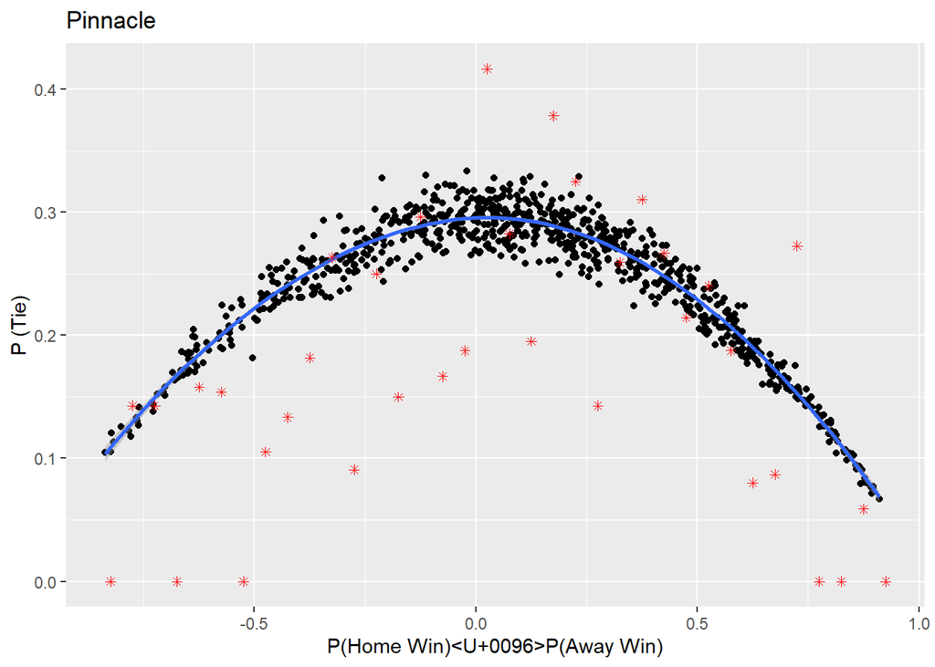

```r
ggplot() +
  geom_point(data=ps, aes(x=ph_pa, y=P_draw))+ geom_smooth(data=ps, aes(x=ph_pa, y=P_draw))+
  geom_point(data=ps_df,aes(x=ort,y=draw_real_prob),colour="red", shape=8)+
  geom_point()+ xlab("P(Home Win)㤼㸶P(Away Win)") +
  ylab("P (Tie)") + ggtitle("Pinnacle")
```

## TASK 3

In this part, matches containing red cards are eliminated from the data since they can create noise in the match outcomes. Plots below show the comparison of actual draw probabilities and bookmakers’ draw probabilites. When the outliers are eliminated, number of stars (actual probability) lying above the points (bookmaker’s probability) are increased specifically in the area near zero.

### Bet 365

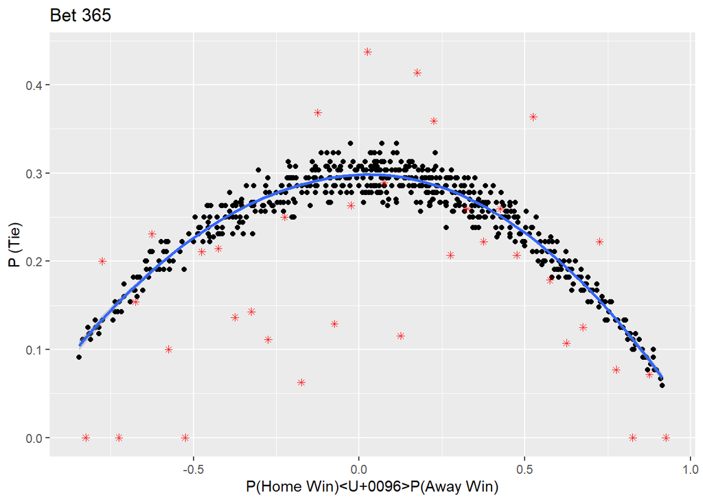

```r
t3_b365<-filter(b365, HR==0 & AR ==0)

t3_b365_df<-t3_b365 %>%
  group_by(p_range) %>%
  summarise(draw_num=sum(is_draw), obs=n())

t3_b365_df$ort<-seq(-0.825,0.925,by=0.05)

t3_b365_df$draw_real_prob<-t3_b365_df$draw_num/t3_b365_df$obs

ggplot() +
  geom_point(data=t3_b365, aes(x=ph_pa, y=P_draw))+ geom_smooth(data=t3_b365, aes(x=ph_pa, y=P_draw))+
  geom_point(data=t3_b365_df,aes(x=ort,y=draw_real_prob),colour="red",shape=8)+
  xlab("P(Home Win)㤼㸶P(Away Win)") +
  ylab("P (Tie)") + ggtitle("Bet 365")
```

### Bet And Win

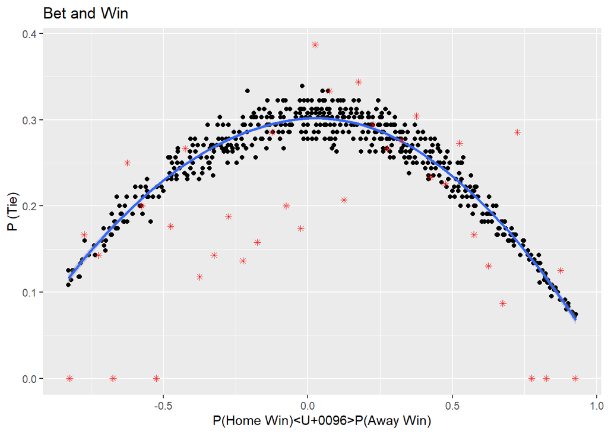

```r
t3_bw<-filter(bw, HR==0 & AR ==0)

t3_bw_df<-t3_bw %>%
  group_by(p_range) %>%
  summarise(draw_num=sum(is_draw), obs=n())

t3_bw_df$ort<-seq(-0.825,0.925,by=0.05)

t3_bw_df$draw_real_prob<-t3_bw_df$draw_num/t3_bw_df$obs

ggplot() +
  geom_point(data=t3_bw, aes(x=ph_pa, y=P_draw))+ geom_smooth(data=t3_bw, aes(x=ph_pa, y=P_draw))+
  geom_point(data=t3_bw_df,aes(x=ort,y=draw_real_prob),colour="red",shape=8)+
  xlab("P(Home Win)㤼㸶P(Away Win)") +
  ylab("P (Tie)") + ggtitle("Bet and Win")
```

### Some Bookmaker

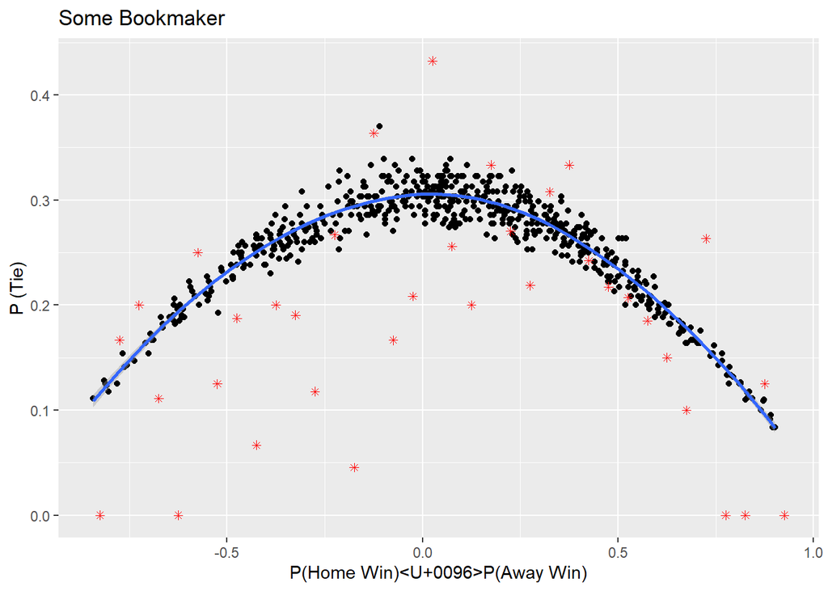

```r
t3_iw<-filter(iw, HR==0 & AR ==0)

t3_iw_df<-t3_iw %>%
  group_by(p_range) %>%
  summarise(draw_num=sum(is_draw), obs=n())

t3_iw_df$ort<-seq(-0.825,0.925,by=0.05)

t3_iw_df$draw_real_prob<-t3_iw_df$draw_num/t3_iw_df$obs

ggplot() +
  geom_point(data=t3_iw, aes(x=ph_pa, y=P_draw))+ geom_smooth(data=t3_iw, aes(x=ph_pa, y=P_draw))+
  geom_point(data=t3_iw_df,aes(x=ort,y=draw_real_prob),colour="red",shape=8)+
  xlab("P(Home Win)㤼㸶P(Away Win)") +
  ylab("P (Tie)") + ggtitle("Some Bookmaker")
```

### Pinnacle

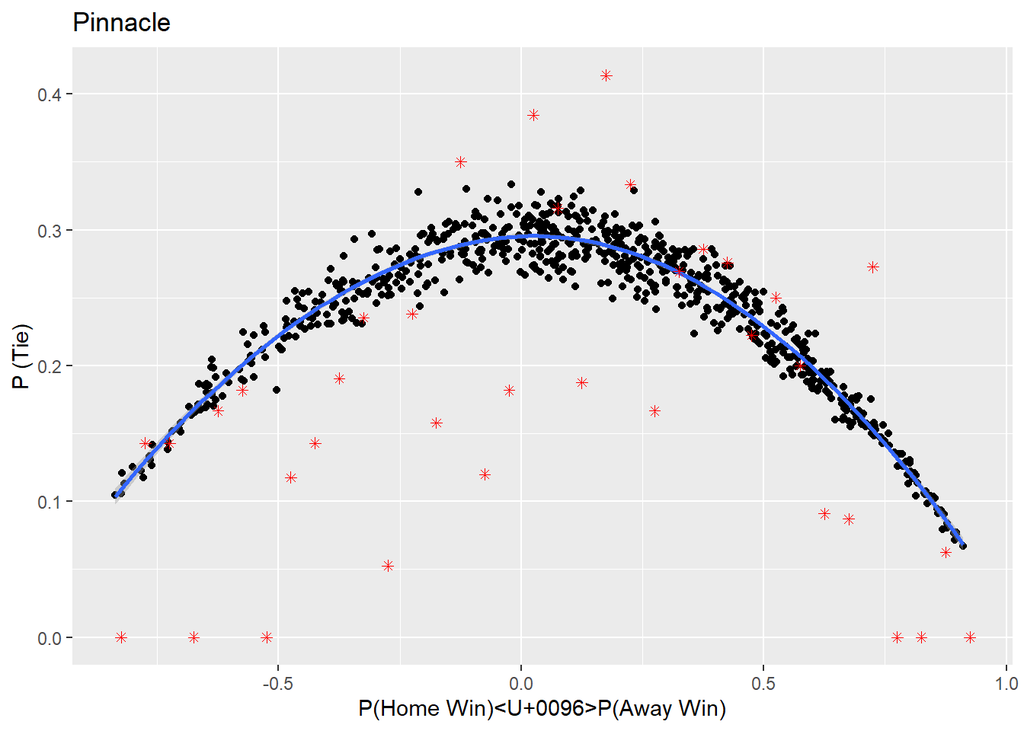

```r
t3_ps<-filter(ps, HR==0 & AR ==0)

t3_ps_df<-t3_ps %>%
  group_by(p_range) %>%
  summarise(draw_num=sum(is_draw), obs=n())

t3_ps_df$ort<-seq(-0.825,0.925,by=0.05)

t3_ps_df$draw_real_prob<-t3_ps_df$draw_num/t3_ps_df$obs

ggplot() +
  geom_point(data=t3_ps, aes(x=ph_pa, y=P_draw))+ geom_smooth(data=t3_ps, aes(x=ph_pa, y=P_draw))+
  geom_point(data=t3_ps_df,aes(x=ort,y=draw_real_prob),colour="red",shape=8)+
  xlab("P(Home Win)㤼㸶P(Away Win)") +
  ylab("P (Tie)") + ggtitle("Pinnacle")
```